# ‘Aping the People’: Populist Identification as Mimesis in Narendra Modi’s Speeches

Anonymous

13/04/2020

# 1 Introduction

## NB for the reader

This is Markdown document of the submitted article **‘Aping the People’: Populist Identification as Mimesis in Narendra Modi’s Speeches**.

# 2 Preparing the corpus for analysis

## Preparation: Step 1

A dataframe is created. CSV and text files are in the same repository. Texts and CSVs are UTF8 formatted, CSV is comma separated.

```r
setwd("C:/Users/jtmartelli/Google Drive/Textual_analysis/R/aping2")
txtvars <-read.csv("metadata.csv",stringsAsFactors = FALSE)
bodytexts <-readtext('*.txt')
bodytexts$id<-gsub('.txt','',bodytexts$doc_id)
dataframe<-merge(bodytexts,txtvars,by='id')
```

## Preparation: Step 2

A corpus called “workcorpus” is generated from the dataframe.

```r
workcorpus <- corpus(dataframe)
texts(workcorpus) <- iconv(texts(workcorpus), from = "UTF-8", to = "ASCII", sub = "")
```

## Preparation: Step 3

A sub-corpus called “subworkcorpus” is created from the corpus “workcorpus” in order to analyze only the speeches of the corpus.

```r
#head(docvars(workcorpus))
subworkcorpus<-corpus_subset(workcorpus, format %in% c('speech'))
ndoc(subworkcorpus)
```

```
## [1] 4199
```

## Preparation: Step 4

The sub-corpus “subworkcorpus” is tokenized.

```r
tokssubworkcorpus <- tokens(subworkcorpus, remove_punct = FALSE, remove_numbers = FALSE, remove_symbols = FALSE, remove_separators = TRUE, remove_hyphens = FALSE, remove_url = FALSE, concatenator = "_")
head(tokssubworkcorpus[[1]], 50)
```

```
##  [1] "Friends"     "and"         "comrades"    ","           "Jai"
##  [6] "Hind"        "!"           "Six"         "days"        "ago"
## [11] ","           "my"          "colleagues"  "and"         "I"
## [16] "sat"         "on"          "the"         "chairs"      "of"
## [21] "high"        "office"      "in"          "the"         "Government"
## [26] "of"          "India"       "."           "A"           "new"
## [31] "Government"  "came"        "into"        "being"       "in"
## [36] "this"        "ancient"     "land"        ","           "the"
## [41] "Interim"     "or"          "Provisional" "Government"  "we"
## [46] "called"      "it"          ","           "the"         "stepping"
```

## Preparation: Step 5

Unigrams proxying entries of variables of interest are replaced by ngrams.

```r
popngrams <- read.csv("C:/Users/jtmartelli/Google Drive/Textual_analysis/R/aping/dictionaries/popngrams.csv", as.is = TRUE, header = FALSE)
dicopopgram <- dictionary(split(popngrams[,2], popngrams[,1]))
ngramstokssubworkcorpus <- tokens_lookup(tokssubworkcorpus, dicopopgram, valuetype = 'glob', exclusive = FALSE, capkeys = FALSE, case_insensitive = TRUE)
```

## Preparation: Step 6

A document-feature matrix is created from the tokenized corpus.

```r
dfmtokssubworkcorpus <- dfm(ngramstokssubworkcorpus, remove_punct = FALSE, tolower = FALSE, dictionary_regex=TRUE, language = "english", stem = FALSE, clean = FALSE, verbose= TRUE) # if no ngram dictionary is loaded, then used the insert tokssubworkcorpus instead.
```

# 3 The analysis

## Dictionaries

```r
#Step 1:
  #Dictionaries are imported. There are two dictionaries: 5-level dictionary (nested lists) used for the analysis and a flat list for comparison purposes (Pauwels 2011). Only the 5-level dictionary is used for the analysis.
popdicoH <- dictionary(file = "C:/Users/jtmartelli/Google Drive/Textual_analysis/R/aping2/dictionaries/populism.yml", tolower = FALSE)
names(popdicoH) #that is the matrix one
```

```
## [1] "poprelatedC" "poprelatedE"
```

```r
popdicoL <- dictionary(list(populism=c("elit*","consensus*","undemocratic*","referend*","currupt*","propagand*","politici*","deceit*","deceiv*","betray*","shame*","scandal*","truth*","dishonest*","establishm*","ruling*","absurd*", "arrogant*", "promis*", "promise*", "capitul*", "direct","mafia","freedom_of_expression","undemocratic","particrat*", "politic*","regime*","shameless","tradition*","people"))) #that is the list-wise dictionary using Pauwels (2011) list.
#Step2:
  #Applying the dictionary to the DFM
popdicodfmHspeech1 <- dfm_lookup(dfmtokssubworkcorpus, dictionary = popdicoH, valuetype = "glob",  levels=1)
popdicodfmHspeech2 <- dfm_lookup(dfmtokssubworkcorpus, dictionary = popdicoH, valuetype = "glob",  levels=2)
popdicodfmHspeech3 <- dfm_lookup(dfmtokssubworkcorpus, dictionary = popdicoH, valuetype = "glob",  levels=3)
popdicodfmHspeech4 <- dfm_lookup(dfmtokssubworkcorpus, dictionary = popdicoH, valuetype = "glob",  levels=4)
popdicodfmHspeech5 <- dfm_lookup(dfmtokssubworkcorpus, dictionary = popdicoH, valuetype = "glob",  levels=5)
```

## Computing the proportions of linguistic measures per PM for the five levels of the dictionary (1:5)

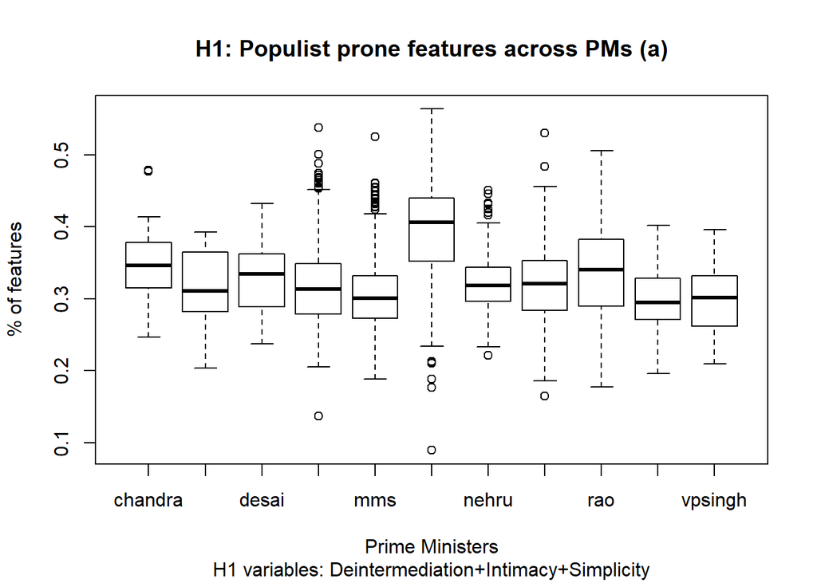

```r
#In order to calculate proportions of linguistic measures among PMs, a column with the features that are not included in the dictionary is added in the DFM.

keeponlydico <- tokens_select(ngramstokssubworkcorpus, pattern = popdicoH, valuetype = 'glob', case_insensitive = FALSE, selection = 'keep')
dfmkeeponlydico <- dfm(keeponlydico, remove_punct = FALSE, tolower = FALSE, dictionary_regex=TRUE, language = "english", stem = FALSE, clean = FALSE, verbose= TRUE)


onlytherest <- tokens_select(ngramstokssubworkcorpus, pattern = popdicoH, valuetype = 'glob', case_insensitive = FALSE, selection = 'remove')
dfmonlytherest <- dfm(onlytherest, remove_punct = FALSE, tolower = FALSE, dictionary_regex=TRUE, language = "english", stem = FALSE, clean = FALSE, verbose= TRUE)

u <-dfmonlytherest
U<-rowSums(u)

#Adding to the DFM a column for Prime Ministers and another one for the year of the speeches

catdfmkeeponlydico1 <- dfm_lookup(dfmkeeponlydico, dictionary = popdicoH, levels=1)

v1<-cbind(catdfmkeeponlydico1,U)
v2<-convert(cbind(dfmtokssubworkcorpus@docvars$year,v1),to="data.frame")
v3<-cbind(dfmtokssubworkcorpus@docvars$loc,v2)

colnames(v3)[1]<-"PM"
colnames(v3)[2]<-"Speech"
colnames(v3)[3]<-"Year"
colnames(v3)[6]<-"TheRest"

catdfmkeeponlydico2 <- dfm_lookup(dfmkeeponlydico, dictionary = popdicoH, levels=2)

v4<-cbind(catdfmkeeponlydico2,U)
v5<-convert(cbind(dfmtokssubworkcorpus@docvars$year,v4),to="data.frame")
v6<-cbind(dfmtokssubworkcorpus@docvars$loc,v5)

colnames(v6)[1]<-"PM"
colnames(v6)[2]<-"Speech"
colnames(v6)[3]<-"Year"
colnames(v6)[8]<-"TheRest"

catdfmkeeponlydico3 <- dfm_lookup(dfmkeeponlydico, dictionary = popdicoH, levels=3)

v7<-cbind(catdfmkeeponlydico3,U)
v8<-convert(cbind(dfmtokssubworkcorpus@docvars$year,v7),to="data.frame")
v9<-cbind(dfmtokssubworkcorpus@docvars$loc,v8)

colnames(v9)[1]<-"PM"
colnames(v9)[2]<-"Speech"
colnames(v9)[3]<-"Year"
colnames(v9)[14]<-"TheRest"

catdfmkeeponlydico4 <- dfm_lookup(dfmkeeponlydico, dictionary = popdicoH, levels=4)

v10<-cbind(catdfmkeeponlydico4,U)
v11<-convert(cbind(dfmtokssubworkcorpus@docvars$year,v10),to="data.frame")
v12<-cbind(dfmtokssubworkcorpus@docvars$loc,v11)

colnames(v12)[1]<-"PM"
colnames(v12)[2]<-"Speech"
colnames(v12)[3]<-"Year"
colnames(v12)[54]<-"TheRest"

catdfmkeeponlydico5 <- dfm_lookup(dfmkeeponlydico, dictionary = popdicoH, levels=5)

v13<-cbind(catdfmkeeponlydico5,U)
v14<-convert(cbind(dfmtokssubworkcorpus@docvars$year,v13),to="data.frame")
v15<-cbind(dfmtokssubworkcorpus@docvars$loc,v14)

colnames(v15)[1]<-"PM"
colnames(v15)[2]<-"Speech"
colnames(v15)[3]<-"Year"
colnames(v15)[8]<-"TheRest"

#Computing the percentage of each column for the different levels of the dictionary

v16 <- v3
for(i in 1:nrow(v3)){
  for(j in 4:ncol(v3)){
    v16[i,j]<-v3[i,j]/sum(v3[i,(4:ncol(v3))])
  }
}

v17 <- v6
for(i in 1:nrow(v6)){
  for(j in 4:ncol(v6)){
    v17[i,j]<-v6[i,j]/sum(v6[i,(4:ncol(v6))])
  }
}

v18 <- v9
for(i in 1:nrow(v9)){
  for(j in 4:ncol(v9)){
    v18[i,j]<-v9[i,j]/sum(v9[i,(4:ncol(v9))])
  }
}

v19 <- v12
for(i in 1:nrow(v12)){
  for(j in 4:ncol(v12)){
    v19[i,j]<-v12[i,j]/sum(v12[i,(4:ncol(v12))])
  }
}

v20 <- v15
for(i in 1:nrow(v15)){
  for(j in 4:ncol(v15)){
    v20[i,j]<-v15[i,j]/sum(v15[i,(4:ncol(v15))])
  }
}

#Grouping dictionary entries in three groups according to their relashionship with populism: prone, averse, neutral

#hypothesis A

proneA<-cbind(v17$popproneC)
averseA<-cbind(v17$popaverseC)
neutralA<-cbind(v17$popproneE+v17$popaverseE+v17$TheRest)

#hypothesis B

proneB<-cbind(v17$popproneE)
averseB<-cbind(v17$popaverseE)
neutralB<-cbind(v17$popproneC+v17$popaverseC+v17$TheRest)

#hypothesis A+B

proneAB<-cbind(v17$popproneC+v17$popproneE)
averseAB<-cbind(v17$popaverseC+v17$popaverseE)
neutralAB<-cbind(v17$TheRest)

#plotting results

plot(v17$PM, proneA, main="H1: Populist prone features across PMs (a)", sub="H1 variables: Deintermediation+Intimacy+Simplicity",
  xlab="Prime Ministers", ylab="% of features")
```

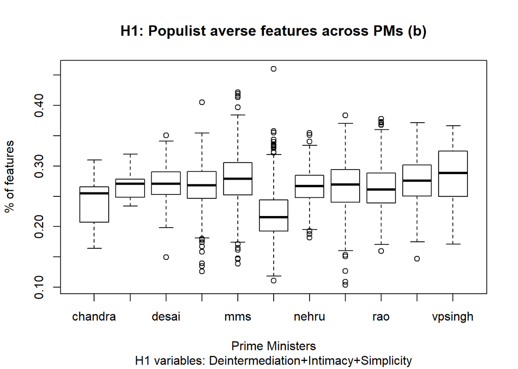

```r
plot(v17$PM, averseA, main="H1: Populist averse features across PMs (b)", sub="H1 variables: Deintermediation+Intimacy+Simplicity",
  xlab="Prime Ministers", ylab="% of features")
```

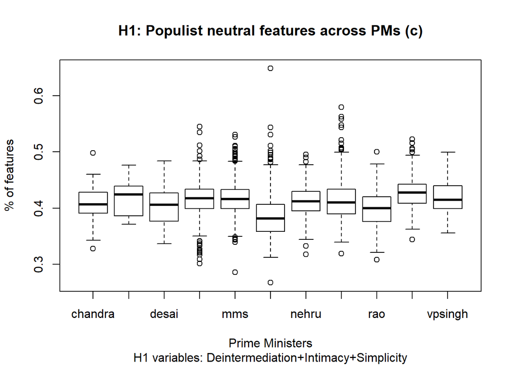

```r
plot(v17$PM, neutralA, main="H1: Populist neutral features across PMs (c)", sub="H1 variables: Deintermediation+Intimacy+Simplicity",
  xlab="Prime Ministers", ylab="% of features")
```

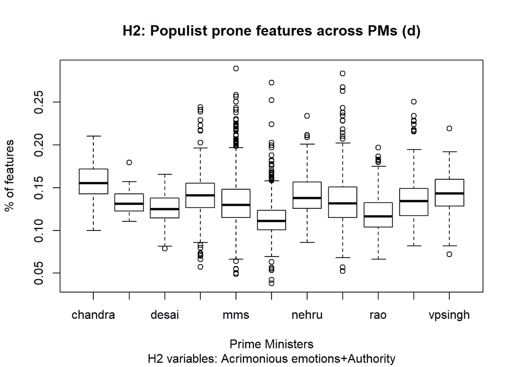

```r
plot(v17$PM, proneB, main="H2: Populist prone features across PMs (d)", sub="H2 variables: Acrimonious emotions+Authority",
  xlab="Prime Ministers", ylab="% of features")
```

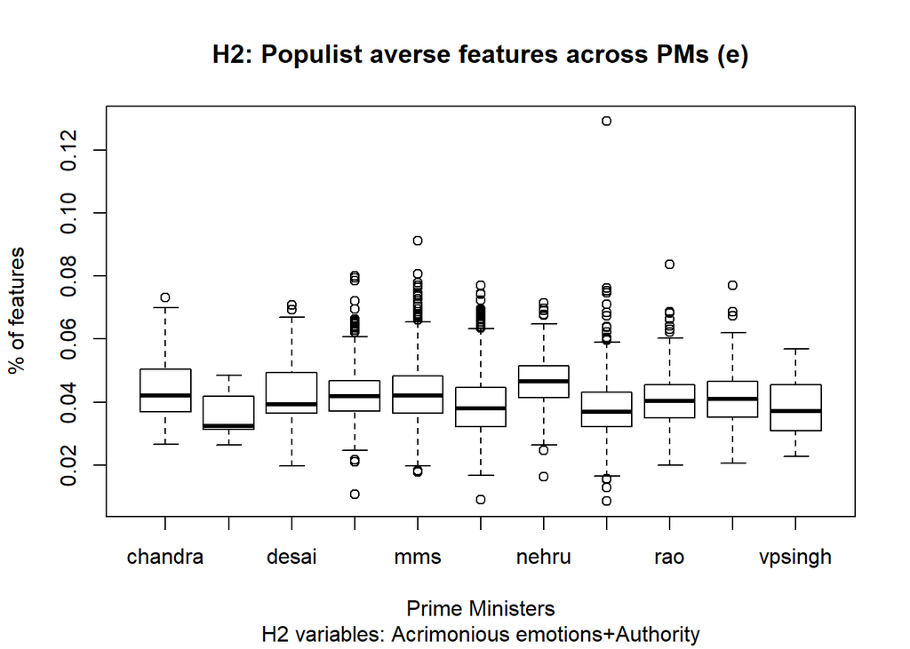

```r
plot(v17$PM, averseB, main="H2: Populist averse features across PMs (e)", sub="H2 variables: Acrimonious emotions+Authority",
  xlab="Prime Ministers", ylab="% of features")
```

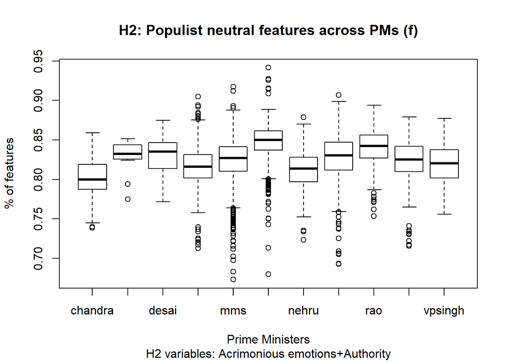

```r
plot(v17$PM, neutralB, main="H2: Populist neutral features across PMs (f)", sub="H2 variables: Acrimonious emotions+Authority",
  xlab="Prime Ministers", ylab="% of features")
```

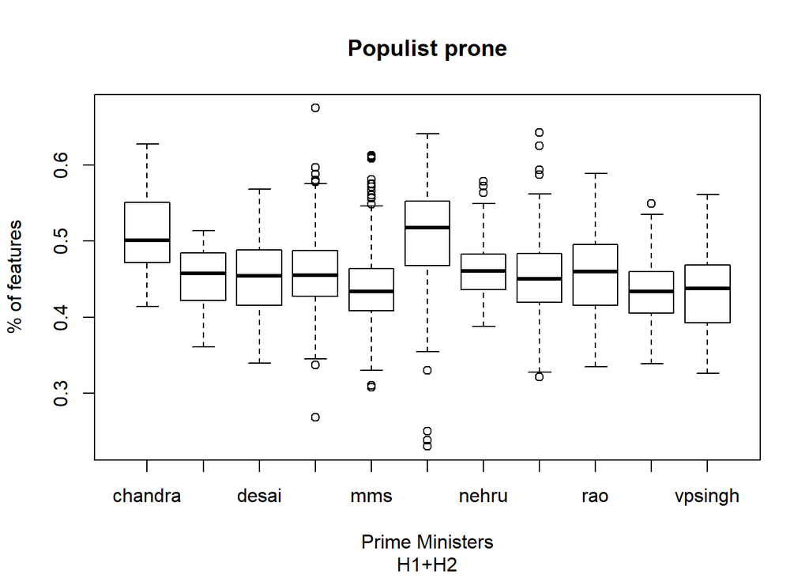

```r
plot(v17$PM, proneAB, main="Populist prone", sub="H1+H2",
  xlab="Prime Ministers", ylab="% of features")
```

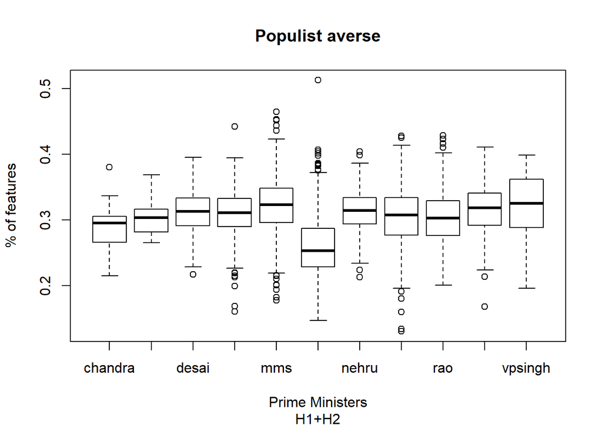

```r
plot(v17$PM, averseAB, main="Populist averse", sub="H1+H2",
  xlab="Prime Ministers", ylab="% of features")
```

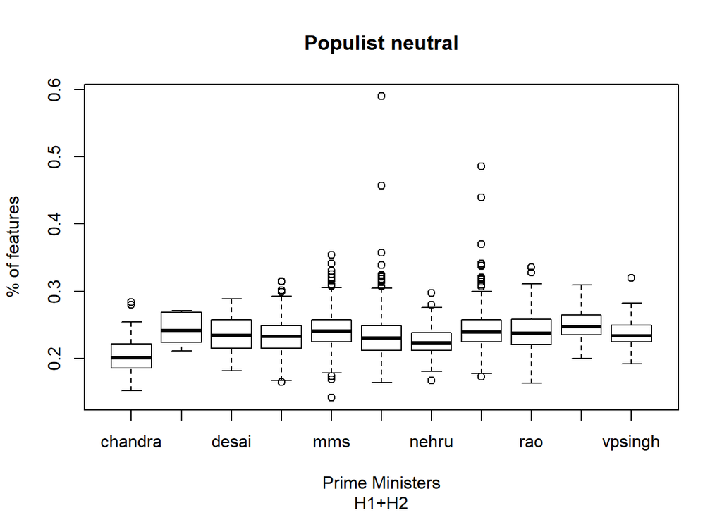

```r
plot(v17$PM, neutralAB, main="Populist neutral", sub="H1+H2",
  xlab="Prime Ministers", ylab="% of features")
```

```r
#Computing Anovas for the selected variables of the different levels of the dictionary

v16t<-v16[,-1:-3]
v16t<-as.matrix(v16t)
PMs<-as.factor(v16$PM)
resultnewanova1 <- aov(v16t~PMs)
#summary(resultnewanova1)
#coefficients(resultnewanova1)

v17t<-v17[,-1:-3]
v17t<-as.matrix(v17t)
PMs<-as.factor(v17$PM)
resultnewanova2 <- aov(v17t~PMs)
#summary(resultnewanova2)
#coefficients(resultnewanova2)
v17a<-cbind(proneA,averseA,neutralA)
PMs<-as.factor(v17$PM)
resultnewanova2a <- aov(v17a~PMs)
#summary(resultnewanova2a)
#coefficients(resultnewanova2a)
v17b<-cbind(proneB,averseB,neutralB)
PMs<-as.factor(v17$PM)
resultnewanova2b <- aov(v17b~PMs)
#summary(resultnewanova2b)
#coefficients(resultnewanova2b)
v17ab<-cbind(proneAB,averseAB,neutralAB)
PMs<-as.factor(v17$PM)
resultnewanova2ab <- aov(v17ab~PMs)
#summary(resultnewanova2ab)
#coefficients(resultnewanova2ab)

v18t<-v18[,-1:-3]
v18t<-as.matrix(v18t)
PMs<-as.factor(v18$PM)
resultnewanova3 <- aov(v18t~PMs)
#summary(resultnewanova3)
#coefficients(resultnewanova3)

v19t<-v19[,-1:-3]
v19t<-as.matrix(v19t)
PMs<-as.factor(v19$PM)
resultnewanova4 <- aov(v19t~PMs)
#summary(resultnewanova4)
#coefficients(resultnewanova4)

v20t<-v20[,-1:-3]
v20t<-as.matrix(v20t)
PMs<-as.factor(v20$PM)
resultnewanova5 <- aov(v20t~PMs)
#summary(resultnewanova5)
#coefficients(resultnewanova5)

#Extracting the F values from the Anovas for the various levels of the dictionary

fvalues1<-c()
for (f in 1:3){
  fvalues1 <- c(fvalues1,summary.aov(resultnewanova1)[[f]][["F value"]][[1]])
}
fvalues1<-round(fvalues1,digits=2)
#fvalues1

fvalues2<-c()
for (f in 1:5){
  fvalues2 <- c(fvalues2,summary.aov(resultnewanova2)[[f]][["F value"]][[1]])
}
fvalues2<-round(fvalues2,digits=2)
#fvalues2

fvalues2a<-c()
for (f in 1:3){
  fvalues2a <- c(fvalues2a,summary.aov(resultnewanova2a)[[f]][["F value"]][[1]])
}
fvalues2a<-round(fvalues2a,digits=2)
#fvalues2a

fvalues2b<-c()
for (f in 1:3){
  fvalues2b <- c(fvalues2b,summary.aov(resultnewanova2b)[[f]][["F value"]][[1]])
}
fvalues2b<-round(fvalues2b,digits=2)
#fvalues2b

fvalues2ab<-c()
for (f in 1:3){
  fvalues2ab <- c(fvalues2ab,summary.aov(resultnewanova2ab)[[f]][["F value"]][[1]])
}
fvalues2ab<-round(fvalues2ab,digits=2)
#fvalues2ab

fvalues3<-c()
for (f in 1:11){
  fvalues3 <- c(fvalues3,summary.aov(resultnewanova3)[[f]][["F value"]][[1]])
}
fvalues3<-round(fvalues3,digits=2)
#fvalues3

fvalues4<-c()
for (f in 1:51){
  fvalues4 <- c(fvalues4,summary.aov(resultnewanova4)[[f]][["F value"]][[1]])
}
fvalues4<-round(fvalues4,digits=2)
#fvalues4

fvalues5<-c()
for (f in 1:5){
  fvalues5 <- c(fvalues5,summary.aov(resultnewanova5)[[f]][["F value"]][[1]])
}
fvalues5<-round(fvalues5,digits=2)
#fvalues5

  #Extracting the effect sizes estimates over every column of the various dictionrary levels

resultanovapm1<-c()
for(i in 1:3)
{
  anovatemp<-aov(v16t[,i]~as.factor(v16$PM))
  correctiontemp<-eta_sq(anovatemp)
  correctionnumeric<-round(as.numeric(as.character(correctiontemp[2])),digits=3)
  resultanovapm1<-c(resultanovapm1,correctionnumeric)
}
#resultanovapm1

resultanovapm2<-c()
for(i in 1:5)
{
  anovatemp<-aov(v17t[,i]~as.factor(v17$PM))
  correctiontemp<-eta_sq(anovatemp)
  correctionnumeric<-round(as.numeric(as.character(correctiontemp[2])),digits=3)
  resultanovapm2<-c(resultanovapm2,correctionnumeric)
}
#resultanovapm2

resultanovapm2a<-c()
for(i in 1:3)
{
  anovatemp<-aov(v17a[,i]~as.factor(v17$PM))
  correctiontemp<-eta_sq(anovatemp)
  correctionnumeric<-round(as.numeric(as.character(correctiontemp[2])),digits=3)
  resultanovapm2a<-c(resultanovapm2a,correctionnumeric)
}
#resultanovapm2a

resultanovapm2b<-c()
for(i in 1:3)
{
  anovatemp<-aov(v17b[,i]~as.factor(v17$PM))
  correctiontemp<-eta_sq(anovatemp)
  correctionnumeric<-round(as.numeric(as.character(correctiontemp[2])),digits=3)
  resultanovapm2b<-c(resultanovapm2b,correctionnumeric)
}
#resultanovapm2b

resultanovapm2ab<-c()
for(i in 1:3)
{
  anovatemp<-aov(v17ab[,i]~as.factor(v17$PM))
  correctiontemp<-eta_sq(anovatemp)
  correctionnumeric<-round(as.numeric(as.character(correctiontemp[2])),digits=3)
  resultanovapm2ab<-c(resultanovapm2ab,correctionnumeric)
}
#resultanovapm2ab

resultanovapm3<-c()
for(i in 1:11)
{
  anovatemp<-aov(v18t[,i]~as.factor(v18$PM))
  correctiontemp<-eta_sq(anovatemp)
  correctionnumeric<-round(as.numeric(as.character(correctiontemp[2])),digits=3)
  resultanovapm3<-c(resultanovapm3,correctionnumeric)
}
#resultanovapm3

resultanovapm4<-c()
for(i in 1:51)
{
  anovatemp<-aov(v19t[,i]~as.factor(v19$PM))
  correctiontemp<-eta_sq(anovatemp)
  correctionnumeric<-round(as.numeric(as.character(correctiontemp[2])),digits=3)
  resultanovapm4<-c(resultanovapm4,correctionnumeric)
}
#resultanovapm4

resultanovapm5<-c()
for(i in 1:5)
{
  anovatemp<-aov(v20t[,i]~as.factor(v20$PM))
  correctiontemp<-eta_sq(anovatemp)
  correctionnumeric<-round(as.numeric(as.character(correctiontemp[2])),digits=3)
  resultanovapm5<-c(resultanovapm5,correctionnumeric)
}
#resultanovapm5

#Labelling the vectors containing the effect sizes and the F values
fvaluesfordf1<-c("F*",fvalues1)
anovaresultsfordf1<-c("n^2",resultanovapm1)

fvaluesfordf2<-c("F*",fvalues2)
anovaresultsfordf2<-c("n^2",resultanovapm2)

fvaluesfordf2a<-c("F*",fvalues2a)
anovaresultsfordf2a<-c("n^2",resultanovapm2a)

fvaluesfordf2b<-c("F*",fvalues2b)
anovaresultsfordf2b<-c("n^2",resultanovapm2b)

fvaluesfordf2ab<-c("F*",fvalues2ab)
anovaresultsfordf2ab<-c("n^2",resultanovapm2ab)

fvaluesfordf3<-c("F*",fvalues3)
anovaresultsfordf3<-c("n^2",resultanovapm3)

fvaluesfordf4<-c("F*",fvalues4)
anovaresultsfordf4<-c("n^2",resultanovapm4)

fvaluesfordf5<-c("F*",fvalues5)
anovaresultsfordf5<-c("n^2",resultanovapm5)

#Removing/adding unnecessary columns

v16u<-v16[,-2:-3]
v17u<-v17[,-2:-3]

v17ua<-cbind(as.character(v17$PM),v17a)
v17ub<-cbind(as.character(v17$PM),v17b)
v17uab<-cbind(as.character(v17$PM),v17ab)

v18u<-v18[,-2:-3]
v19u<-v19[,-2:-3]
v20u<-v20[,-2:-3]


#Grouping the results by Prime Minister


v16v<-aggregate(v16u, by=list(v16u$PM),FUN=mean,na.action = na.omit)
v16v$PM <- NULL
colnames(v16v)[1]<-"PM"

v17v<-aggregate(v17u, by=list(v17u$PM),FUN=mean,na.action = na.omit)
v17v$PM <- NULL
colnames(v17v)[1]<-"PM"

v17va<-aggregate(v17a, by=list(v17u$PM),FUN=mean,na.action = na.omit)
colnames(v17va)[1]<-"PM"
colnames(v17va)[2]<-"proneA"
colnames(v17va)[3]<-"averseA"
colnames(v17va)[4]<-"neutralA"

v17vb<-aggregate(v17b, by=list(v17u$PM),FUN=mean,na.action = na.omit)
colnames(v17vb)[1]<-"PM"
colnames(v17vb)[2]<-"proneB"
colnames(v17vb)[3]<-"averseB"
colnames(v17vb)[4]<-"neutralB"

v17vab<-aggregate(v17ab, by=list(v17u$PM),FUN=mean,na.action = na.omit)
colnames(v17vab)[1]<-"PM"
colnames(v17vab)[2]<-"proneAB"
colnames(v17vab)[3]<-"averseAB"
colnames(v17vab)[4]<-"neutralAB"

v18v<-aggregate(v18u, by=list(v18u$PM),FUN=mean,na.action = na.omit)
v18v$PM <- NULL
colnames(v18v)[1]<-"PM"

v19v<-aggregate(v19u, by=list(v19u$PM),FUN=mean,na.action = na.omit)
v19v$PM <- NULL
colnames(v19v)[1]<-"PM"

v20v<-aggregate(v20u, by=list(v20u$PM),FUN=mean,na.action = na.omit)
v20v$PM <- NULL
colnames(v20v)[1]<-"PM"


#Rounding the results

v16V <- v16v
for(i in 1:nrow(v16V)){
  for(j in 2:ncol(v16V)){
v16V[i,j]<-round(v16V[i,j],digits=3)
  }
}

v17V <- v17v
for(i in 1:nrow(v17V)){
  for(j in 2:ncol(v17V)){
v17V[i,j]<-round(v17V[i,j],digits=3)
  }
}

v17VA <- v17va
for(i in 1:nrow(v17VA)){
  for(j in 2:ncol(v17VA)){
v17VA[i,j]<-round(as.numeric(v17VA[i,j]),digits=3)
  }
}

v17VB <- v17vb
for(i in 1:nrow(v17VB)){
  for(j in 2:ncol(v17VB)){
v17VB[i,j]<-round(as.numeric(v17VB[i,j]),digits=3)
  }
}

v17VAB <- v17vab
for(i in 1:nrow(v17VAB)){
  for(j in 2:ncol(v17VAB)){
v17VAB[i,j]<-round(as.numeric(v17VAB[i,j]),digits=3)
  }
}

v18V <- v18v
for(i in 1:nrow(v18V)){
  for(j in 2:ncol(v18V)){
v18V[i,j]<-round(v18V[i,j],digits=3)
  }
}


v19V <- v19v
for(i in 1:nrow(v19V)){
  for(j in 2:ncol(v19V)){
v19V[i,j]<-round(v19V[i,j],digits=3)
  }
}


v20V <- v20v
for(i in 1:nrow(v20V)){
  for(j in 2:ncol(v20V)){
v20V[i,j]<-round(v20V[i,j],digits=3)
  }
}

#Putting the Anova and effect sizes at the end of the tables of proportions for each dictionary level (Table 2, base for Figure 3)

x<-rbind(as.matrix(v16V),fvaluesfordf1,anovaresultsfordf1)
pretable1 <- x[,-1]
rownames(pretable1) <- x[,1]

x<-rbind(as.matrix(v17V),fvaluesfordf2,anovaresultsfordf2)
pretable2 <- x[,-1]
rownames(pretable2) <- x[,1]

x<-rbind(as.matrix(v17VA),fvaluesfordf2a,anovaresultsfordf2a)
pretable2a <- x[,-1]
rownames(pretable2a) <- x[,1]

x<-rbind(as.matrix(v17VB),fvaluesfordf2b,anovaresultsfordf2b)
pretable2b <- x[,-1]
rownames(pretable2b) <- x[,1]

x<-rbind(as.matrix(v17VAB),fvaluesfordf2ab,anovaresultsfordf2ab)
pretable2ab <- x[,-1]
rownames(pretable2ab) <- x[,1]

x<-rbind(as.matrix(v18V),fvaluesfordf3,anovaresultsfordf3)
pretable3 <- x[,-1]
rownames(pretable3) <- x[,1]

x<-rbind(as.matrix(v19V),fvaluesfordf4,anovaresultsfordf4)
pretable4 <- x[,-1]
rownames(pretable4) <- x[,1]

x<-rbind(as.matrix(v20V),fvaluesfordf5,anovaresultsfordf5)
pretable5 <- x[,-1]
rownames(pretable5) <- x[,1]
```

## Computing the ratios of prone/averse features of linguistic measures per PM for the various levels of the dictionary

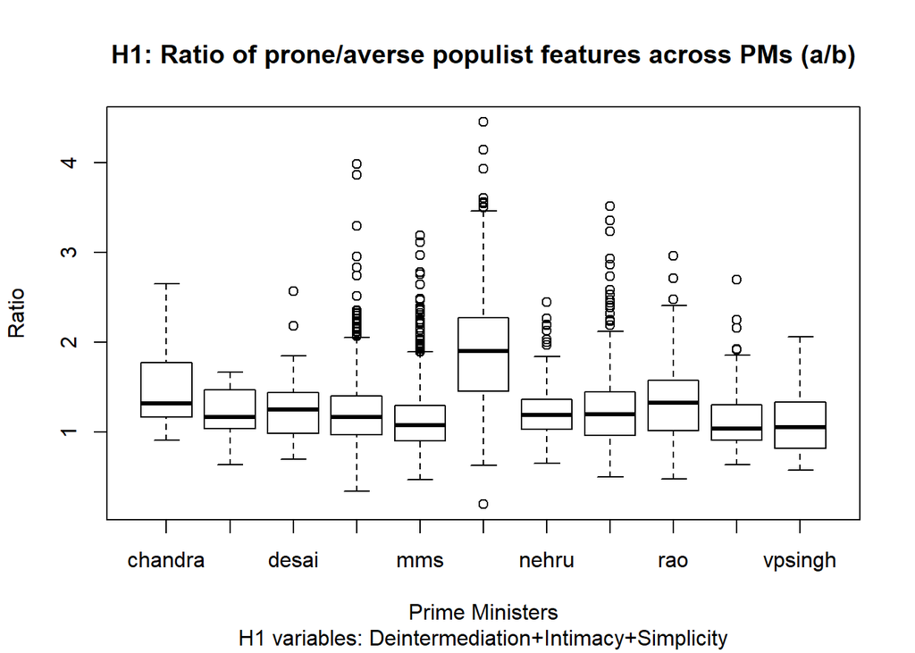

```r
#The ratio populist prone/populist averse (dictionary level 2) is generated for the two model specifications (Hypothesis 1 and 2)

popproneC <- cbind(v17$popproneC)
popaverseC <- cbind(v17$popaverseC)
ratioC <- as.matrix(popproneC/popaverseC)

popproneE <- cbind(v17$popproneE)
popaverseE <- cbind(v17$popaverseE)
ratioE <- as.matrix(popproneE/popaverseE)

v21<-v17[,-4:-8]
ratiosCE <- data.frame(v21,ratioC,ratioE)

#The ratios prone/averse for other dictionary levels (H1: Deintermediation+Intimacy+Simplicity, H2: Acrimonious emotions+Authority) are generated

deintermediationprone <- cbind(v18$deintermediationprone)
deintermediationaverse <- cbind(v18$deintermediationaverse)
H1.deintermediation<- as.matrix(deintermediationprone/deintermediationaverse)

intimacyprone <- cbind(v18$intimacyprone)
intimacyaverse <- cbind(v18$intimacyaverse)
H1.intimacy<- as.matrix(intimacyprone/intimacyaverse)

simplicityprone <- cbind(v18$simplicityprone)
simplicityaverse <- cbind(v18$simplicityaverse)
H1.simplicity<- as.matrix(simplicityprone/simplicityaverse)

emoacrimonyprone <- cbind(v18$emoacrimonyprone)
emoacrimonyaverse <- cbind(v18$emoacrimonyaverse)
H2.neg.emotions<- as.matrix(emoacrimonyprone/emoacrimonyaverse)

authorityprone <- cbind(v18$authorityprone)
authorityaverse <- cbind(v18$authorityaverse)
H2.authority<- as.matrix(authorityprone/authorityaverse)

v22<-v18[,-4:-14]
varsCE <- data.frame(v22,H1.deintermediation,H1.intimacy,H1.simplicity,H2.neg.emotions,H2.authority)

#Plotting results for the populist prone/populist averse ratio (dictionary level 2) for H1 and H2 (base for Figure 4)

plot(v21$PM, ratioC, main="H1: Ratio of prone/averse populist features across PMs (a/b)", sub="H1 variables: Deintermediation+Intimacy+Simplicity", xlab="Prime Ministers", ylab="Ratio")
```

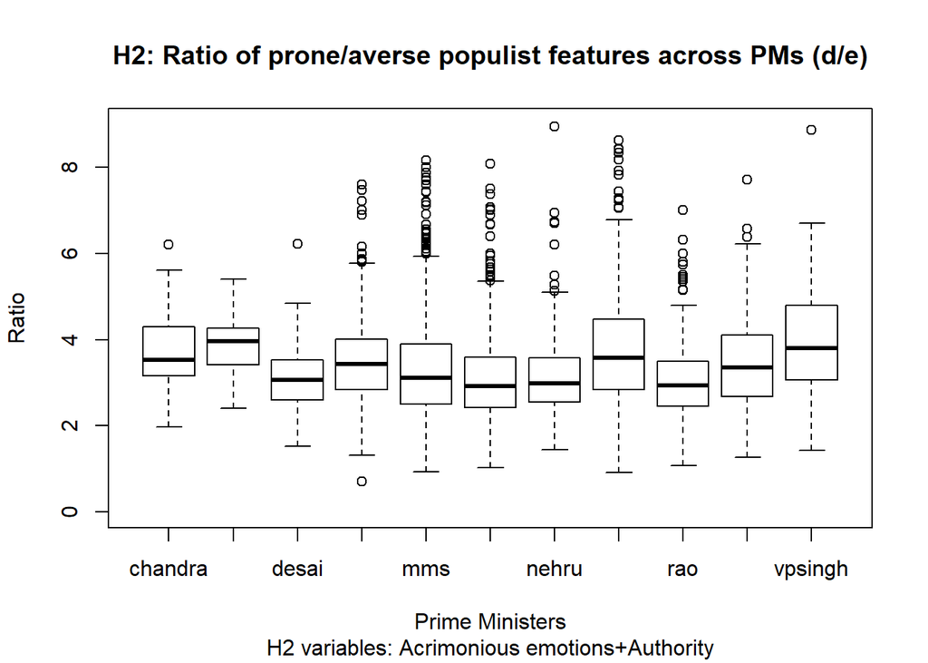

```r
plot(v21$PM, ratioE, main="H2: Ratio of prone/averse populist features across PMs (d/e)", sub="H2 variables: Acrimonious emotions+Authority", xlab="Prime Ministers", ylab="Ratio", ylim = c(0, 9))
```

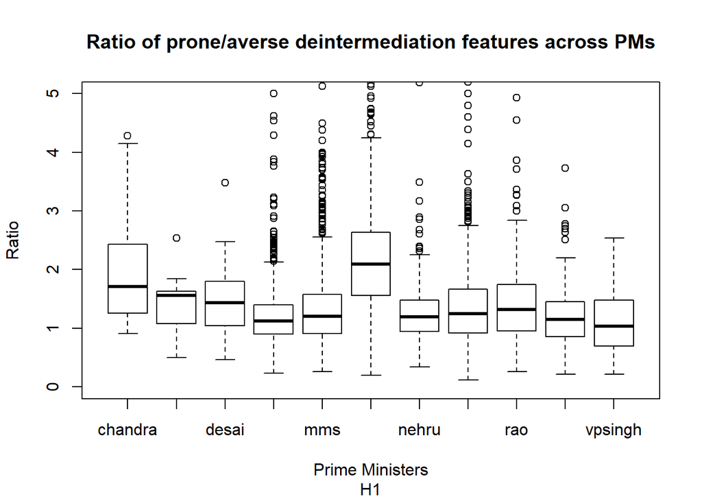

```r
#Plotting results for the prone/averse ratios (H1, H2) for other dictionary levels

plot(v22$PM, H1.deintermediation, main="Ratio of prone/averse deintermediation features across PMs", sub="H1", xlab="Prime Ministers", ylab="Ratio", ylim = c(0, 5))
```

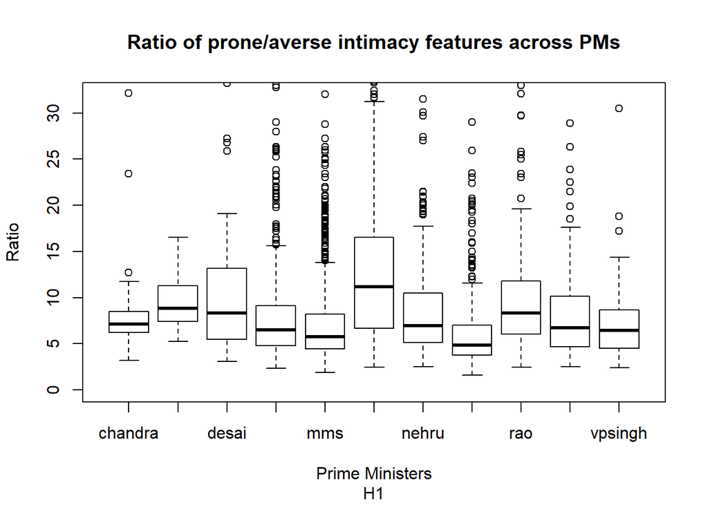

```r
plot(v22$PM, H1.intimacy, main="Ratio of prone/averse intimacy features across PMs", sub="H1", xlab="Prime Ministers", ylab="Ratio", ylim = c(0, 32))
```

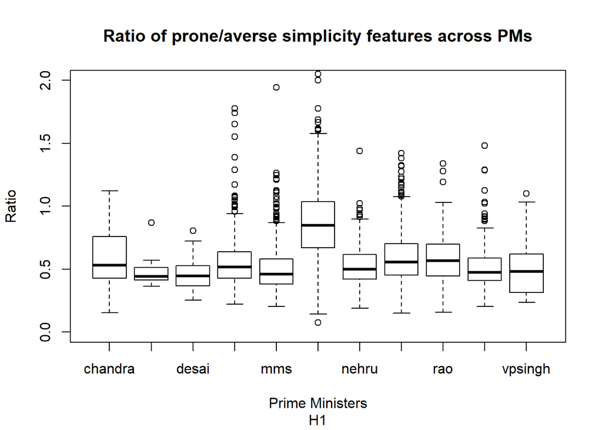

```r
plot(v22$PM, H1.simplicity, main="Ratio of prone/averse simplicity features across PMs", sub="H1", xlab="Prime Ministers", ylab="Ratio", ylim = c(0, 2))
```

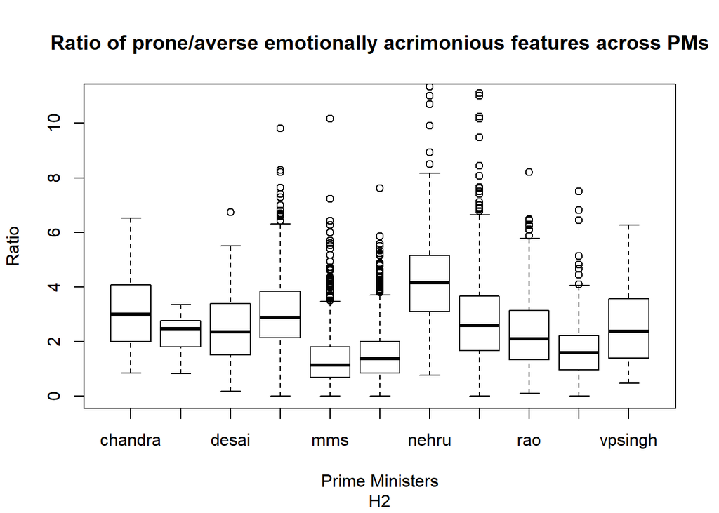

```r
plot(v22$PM, H2.neg.emotions, main="Ratio of prone/averse emotionally acrimonious features across PMs", sub="H2", xlab="Prime Ministers", ylab="Ratio", ylim = c(0, 11))
```

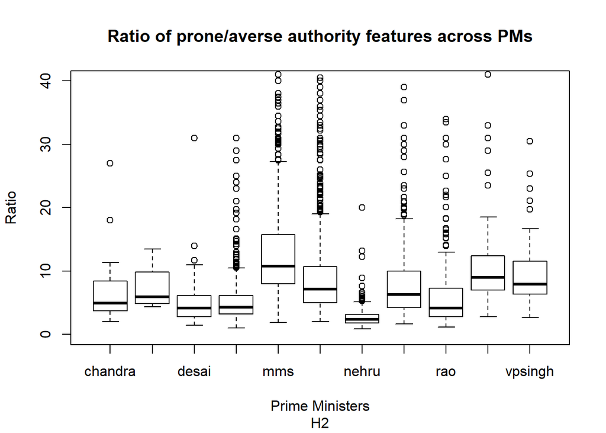

```r
plot(v22$PM, H2.authority, main="Ratio of prone/averse authority features across PMs", sub="H2", xlab="Prime Ministers", ylab="Ratio", ylim = c(0, 40))
```

```r
#Grouping the results by Prime Minister

ratiosCEv<-aggregate(ratiosCE, by=list(ratiosCE$PM),FUN=mean,na.action = na.omit)
ratiosCEv$PM <- NULL
ratiosCEv$Speech <- NULL
ratiosCEv$Year <- NULL
colnames(ratiosCEv)[1]<-"PM"

#Computing Anovas for the populist prone/populist averse ratios (dictionary level 2) for H1 and H2

ratiosCEt<-ratiosCE[,-1:-3]
ratiosCEt<-as.matrix(ratiosCEt)
PMs<-as.factor(ratiosCE$PM)
resultnewanova6 <- aov(ratiosCEt~PMs)
#summary(resultnewanova6)
#coefficients(resultnewanova6)

#Extracting the F values from the Anovas for the various dictionary levels

fvalues6<-c()
for (f in 1:2){
  fvalues6 <- c(fvalues6,summary.aov(resultnewanova6)[[f]][["F value"]][[1]])
}
fvalues6<-round(fvalues6,digits=3)
#fvalues6

#Extracting the effect sizes estimates over every column of the various dictionary levels

resultanovapm6<-c()
for(i in 1:2)
{
  anovatemp<-aov(ratiosCEt[,i]~as.factor(ratiosCE$PM))
  correctiontemp<-eta_sq(anovatemp)
  correctionnumeric<-round(as.numeric(as.character(correctiontemp[2])),digits=3)
  resultanovapm6<-c(resultanovapm6,correctionnumeric)
}
#resultanovapm6

#Labelling the vectors containing the effect sizes and the F values

fvaluesfordf6<-c("F*",fvalues6)
anovaresultsfordf6<-c("n^2",resultanovapm6)

#Rounding the results

ratiosCEV <- ratiosCEv
for(i in 1:nrow(ratiosCEV)){
  for(j in 2:ncol(ratiosCEV)){
ratiosCEV[i,j]<-round(ratiosCEV[i,j],digits=3)
  }
}

#Putting the Anova results and effect sizes at the end of the table of prone/populist averse ratios (dictionary level 2) for H1 and H2

x<-rbind(as.matrix(ratiosCEV),fvaluesfordf6,anovaresultsfordf6)
pretable6 <- x[,-1]
rownames(pretable6) <- x[,1]
```

## Computing the ratios of prone/averse features of linguistic measures time-wise for the various levels of the dictionary

```r
#A generalized linear model is computed on the populist categories (dictionary level 4) for H1 and H2

lm.h1a <- glm(v19$Year ~ v19$longwords + v19$cognitivepro + v19$conceptualnotion + v19$principles + v19$institutionalpro + v19$politicalparties + v19$we + v19$assent + v19$insight + v19$thirdsp + v19$family + v19$religion + v19$gendered + v19$leisure + v19$body + v19$health + v19$friends + v19$home + v19$pronouns + v19$phyfeel + v19$foodfarm + v19$money + v19$festival + v19$elite + v19$nonelite + v19$shortsentences + v19$numbers + v19$pastfocus + v19$culturalnationalism + v19$time + v19$iyou + v19$electoralpro + v19$personalgov + v19$rhetoricalq + v19$futurefocus + v19$persreward + v19$persreward + v19$motion)
#summary(lm.h1a)

lm.h2a <- glm(v19$Year ~ v19$positiveemo + v19$tentative + v19$negativeemo + v19$anger + v19$anxiety + v19$sadness + v19$swearwords + v19$risk + v19$communities + v19$conflict + v19$certainty + v19$achieve + v19$power)
#summary(lm.h2a)

#A generalized linear model is computed on the variables (dicitonary level 3)

lm.h1b <- glm(v18$Year ~  v18$simplicityaverse + v18$deintermediationaverse + v18$intimacyaverse + v18$intimacyprone + v18$simplicityprone + v18$deintermediationprone)
#summary(lm.h1b)

lm.h2b <- glm(v18$Year ~ v18$emoacrimonyaverse + v18$authorityaverse + v18$emoacrimonyprone + v18$authorityprone)
#summary(lm.h2b)

#A linear model is computed on the populist ratios (dictionary level 2)

lm.h1c <- lm(ratiosCE$Year ~ ratiosCE$ratioC)
#summary(lm.h1c)

lm.h2c <- lm(ratiosCE$Year ~ ratiosCE$ratioE)
#summary(lm.h2c)

y<-ratiosCE$ratioC
#plot(y~as.numeric(ratiosCE$Year))
z<-ratiosCE$ratioE
#plot(e~as.numeric(ratiosCE$Year))

#Compute the mean of scores for each year
avplotyear<-c() #empty vector
sdplotyear<-c()
for(i in unique(ratiosCE$Year)){ #takes all the years mentioned once
  allratiosperyear<-ratiosCE[ratiosCE[,3]==i,4] #finds out all the rows in column 4 with year == i
  sdperyear<-sd(allratiosperyear)
  averageplot<-sum(allratiosperyear)/length(allratiosperyear) #computes the average for each year
  avplotyear<-rbind(avplotyear,c(i,averageplot))#binds year and averages
  sdplotyear<-rbind(sdplotyear,c(i,sdperyear))#binds year and standard deviations
}

avplotyear2<-c() #empty vector
sdplotyear2<-c()
for(i in unique(ratiosCE$Year)){ #takes all the years mentioned once
  allratiosperyear2<-ratiosCE[ratiosCE[,3]==i,5] #finds out all the rows in column 4 with year == i
  sdperyear2<-sd(allratiosperyear2)
  averageplot2<-sum(allratiosperyear2)/length(allratiosperyear2) #computes the average for each year
  avplotyear2<-rbind(avplotyear2,c(i,averageplot2))#binds year and averages
  sdplotyear2<-rbind(sdplotyear2,c(i,sdperyear2))#binds year and standard deviations
}
```